# Dimensionality Reduction and Feature Selection

Bundi Kirimi

2/4/2022

#Installing packages.

```r
#install.packages("devtools")

#install_github("vqv/ggbiplot")
#install.packages("rtools")
#install.packages("DataExplorer")
#install.packages("Hmisc")
#install.packages("pastecs")
#install.packages("psych")
#install.packages("corrplot")
#install.packages("factoextra")
#install.packages("caret")
```

#Loading the libraries

```r
#specify the path where the file is located
library("data.table")
library(tidyverse)
library(magrittr)
```

```r
library(warn = -1)
library("ggbiplot")
library(ggplot2)
library(lattice)
library(corrplot)
library(DataExplorer)
library(pastecs)
library(psych)
library(factoextra)
library(caret)
library(data.table)
```

```r
getwd()
```

```
## [1] "C:/Users/Jerome/Documents/R_Project2"
```

#Loading the data

```r
library(readr)
df <- read.csv("Supermarket_Dataset_1 - Sales Data.csv",sep = ",", dec = ".")

df
```

```
##       Invoice.ID Branch Customer.type Gender           Product.line Unit.price
## 1    750-67-8428      A        Member Female      Health and beauty      74.69
## 2    226-31-3081      C        Normal Female Electronic accessories      15.28
## 3    631-41-3108      A        Normal   Male     Home and lifestyle      46.33
## 4    123-19-1176      A        Member   Male      Health and beauty      58.22
## 5    373-73-7910      A        Normal   Male      Sports and travel      86.31
## 6    699-14-3026      C        Normal   Male Electronic accessories      85.39
## 7    355-53-5943      A        Member Female Electronic accessories      68.84
## 8    315-22-5665      C        Normal Female     Home and lifestyle      73.56
## 9    665-32-9167      A        Member Female      Health and beauty      36.26
## 10   692-92-5582      B        Member Female     Food and beverages      54.84
## 11   351-62-0822      B        Member Female    Fashion accessories      14.48
## 12   529-56-3974      B        Member   Male Electronic accessories      25.51
## 13   365-64-0515      A        Normal Female Electronic accessories      46.95
## 14   252-56-2699      A        Normal   Male     Food and beverages      43.19
```

[output cut: 2988 more lines]

#Previewing the summary of the dataset

```r
summary(df)
```

```
##   Invoice.ID           Branch          Customer.type         Gender
##  Length:1000        Length:1000        Length:1000        Length:1000
##  Class :character   Class :character   Class :character   Class :character
##  Mode  :character   Mode  :character   Mode  :character   Mode  :character
##
##
##
##  Product.line         Unit.price       Quantity          Tax
##  Length:1000        Min.   :10.08   Min.   : 1.00   Min.   : 0.5085
##  Class :character   1st Qu.:32.88   1st Qu.: 3.00   1st Qu.: 5.9249
##  Mode  :character   Median :55.23   Median : 5.00   Median :12.0880
##                     Mean   :55.67   Mean   : 5.51   Mean   :15.3794
##                     3rd Qu.:77.94   3rd Qu.: 8.00   3rd Qu.:22.4453
##                     Max.   :99.96   Max.   :10.00   Max.   :49.6500
##      Date               Time             Payment               cogs
##  Length:1000        Length:1000        Length:1000        Min.   : 10.17
##  Class :character   Class :character   Class :character   1st Qu.:118.50
##  Mode  :character   Mode  :character   Mode  :character   Median :241.76
##                                                           Mean   :307.59
##                                                           3rd Qu.:448.90
##                                                           Max.   :993.00
##  gross.margin.percentage  gross.income         Rating           Total
##  Min.   :4.762           Min.   : 0.5085   Min.   : 4.000   Min.   :  10.68
##  1st Qu.:4.762           1st Qu.: 5.9249   1st Qu.: 5.500   1st Qu.: 124.42
##  Median :4.762           Median :12.0880   Median : 7.000   Median : 253.85
##  Mean   :4.762           Mean   :15.3794   Mean   : 6.973   Mean   : 322.97
##  3rd Qu.:4.762           3rd Qu.:22.4453   3rd Qu.: 8.500   3rd Qu.: 471.35
##  Max.   :4.762           Max.   :49.6500   Max.   :10.000   Max.   :1042.65
```

#Checking the data

```r
#Length
length(df)
```

```
## [1] 16
```

```r
#Dimensions
dim(df)
```

```
## [1] 1000   16
```

```r
colnames(df)
```

```
##  [1] "Invoice.ID"              "Branch"
##  [3] "Customer.type"           "Gender"
##  [5] "Product.line"            "Unit.price"
##  [7] "Quantity"                "Tax"
##  [9] "Date"                    "Time"
## [11] "Payment"                 "cogs"
## [13] "gross.margin.percentage" "gross.income"
## [15] "Rating"                  "Total"
```

Column data types

```r
sapply(df, class)
```

```
##              Invoice.ID                  Branch           Customer.type
##             "character"             "character"             "character"
##                  Gender            Product.line              Unit.price
##             "character"             "character"               "numeric"
##                Quantity                     Tax                    Date
##               "integer"               "numeric"             "character"
##                    Time                 Payment                    cogs
##             "character"             "character"               "numeric"
## gross.margin.percentage            gross.income                  Rating
##               "numeric"               "numeric"               "numeric"
##                   Total
##               "numeric"
```

#Data Cleaning

```r
any(is.na(df))
```

```
## [1] FALSE
```

NO NULL VALUES IN OUR DATA

#Data Types

```r
sapply(df, class)
```

```
##              Invoice.ID                  Branch           Customer.type
##             "character"             "character"             "character"
##                  Gender            Product.line              Unit.price
##             "character"             "character"               "numeric"
##                Quantity                     Tax                    Date
##               "integer"               "numeric"             "character"
##                    Time                 Payment                    cogs
##             "character"             "character"               "numeric"
## gross.margin.percentage            gross.income                  Rating
##               "numeric"               "numeric"               "numeric"
##                   Total
##               "numeric"
```

Checking the categories in categorical columns

```r
unique(df$Branch)
```

```
## [1] "A" "C" "B"
```

```r
unique(df$Customer.type)
```

```
## [1] "Member" "Normal"
```

```r
unique(df$Gender)
```

```
## [1] "Female" "Male"
```

```r
unique(df$Product.line )
```

```
## [1] "Health and beauty"      "Electronic accessories" "Home and lifestyle"
## [4] "Sports and travel"      "Food and beverages"     "Fashion accessories"
```

```r
unique(df$Payment)
```

```
## [1] "Ewallet"     "Cash"        "Credit card"
```

```r
unique(df$ Rating)
```

```
##  [1]  9.1  9.6  7.4  8.4  5.3  4.1  5.8  8.0  7.2  5.9  4.5  6.8  7.1  8.2  5.7
## [16]  4.6  6.9  8.6  4.4  4.8  5.1  9.9  6.0  8.5  6.7  7.7  7.5  7.0  4.7  7.6
## [31]  7.9  6.3  5.6  9.5  8.1  6.5  6.1  6.6  5.4  9.3 10.0  6.4  4.3  4.0  8.7
## [46]  9.4  5.5  8.3  7.3  4.9  4.2  9.2  7.8  5.2  9.0  8.8  6.2  9.8  9.7  5.0
## [61]  8.9
```

```r
# Convert data types using as.integer
# Branch
# Convert data types using as.integer
# Branch
df$Branch_E<-as.integer(as.factor(df$Branch))
# Customer Type
df$Customer_Type_E<-as.integer(as.factor(df$Customer.type))
# Gender
df$Gender_E<-as.integer(as.factor(df$Gender))
# Product.line
df$Product_Line_E<-as.integer(as.factor(df$Product.line))
#Payment
df$Payment_E<-as.integer(as.factor(df$Payment))
```

Splitting Date_Time

```r
library("lubridate")
library("ymd")
# Split date year, month and day.
# Convert to date datatype first then split thereafter
df$Date <- as.Date(df$Date, "%m/%d/%Y")
df$year <- year(ymd(df$Date))
df$month <- month(ymd(df$Date))
df$day <- day(ymd(df$Date))
df$hour = format(strptime(df$Time,"%H:%M"),'%H')
df$minute = format(strptime(df$Time,"%H:%M"),'%M')
```

```r
#install.packages(dplyr)
library(dplyr)
```

```r
df_sales_num <- select_if(df,is.numeric)
str(df_sales_num)
```

```
## 'data.frame':    1000 obs. of  16 variables:
##  $ Unit.price             : num  74.7 15.3 46.3 58.2 86.3 ...
##  $ Quantity               : int  7 5 7 8 7 7 6 10 2 3 ...
##  $ Tax                    : num  26.14 3.82 16.22 23.29 30.21 ...
##  $ cogs                   : num  522.8 76.4 324.3 465.8 604.2 ...
##  $ gross.margin.percentage: num  4.76 4.76 4.76 4.76 4.76 ...
##  $ gross.income           : num  26.14 3.82 16.22 23.29 30.21 ...
##  $ Rating                 : num  9.1 9.6 7.4 8.4 5.3 4.1 5.8 8 7.2 5.9 ...
##  $ Total                  : num  549 80.2 340.5 489 634.4 ...
##  $ Branch_E               : int  1 3 1 1 1 3 1 3 1 2 ...
##  $ Customer_Type_E        : int  1 2 2 1 2 2 1 2 1 1 ...
##  $ Gender_E               : int  1 1 2 2 2 2 1 1 1 1 ...
##  $ Product_Line_E         : int  4 1 5 4 6 1 1 5 4 3 ...
##  $ Payment_E              : int  3 1 2 3 3 3 3 3 2 2 ...
##  $ year                   : num  2019 2019 2019 2019 2019 ...
##  $ month                  : num  1 3 3 1 2 3 2 2 1 2 ...
##  $ day                    : int  5 8 3 27 8 25 25 24 10 20 ...
```

Identifying colums variance

A variance of zero indicates that all of the data values are identical. All non-zero variances are positive. A small variance indicates that the data points tend to be very close to the mean, and to each other. We will drop the colum with zero variance as its not necessarry in our analysis because all the values are identical

```r
# Identify the columns with zero column variance.
names(df_sales_num[, sapply(df_sales_num, function(v) var(v,
na.rm=TRUE)==0)])
```

```
## [1] "gross.margin.percentage" "year"
```

```r
# Drop the columns as they have a variance of 0"
df_sales_num <- subset(df_sales_num, select = -c(gross.margin.percentage,
year))
```

```r
dim(df_sales_num)
```

```
## [1] 1000   14
```

```r
standard_sales <- as.data.frame(scale(df_sales_num[1:14])) # standardise the variables
standard_sales.pca <- prcomp(standard_sales)
```

```r
summary(standard_sales.pca)
```

```
## Importance of components:
##                           PC1     PC2     PC3     PC4     PC5     PC6     PC7
## Standard deviation     2.2203 1.08227 1.06969 1.02580 1.00895 0.99359 0.97647
## Proportion of Variance 0.3521 0.08367 0.08173 0.07516 0.07271 0.07052 0.06811
## Cumulative Proportion  0.3521 0.43578 0.51751 0.59267 0.66538 0.73590 0.80401
##                            PC8     PC9   PC10    PC11      PC12      PC13
## Standard deviation     0.96596 0.94903 0.9057 0.29961 3.663e-16 2.375e-16
## Proportion of Variance 0.06665 0.06433 0.0586 0.00641 0.000e+00 0.000e+00
## Cumulative Proportion  0.87066 0.93499 0.9936 1.00000 1.000e+00 1.000e+00
##                             PC14
## Standard deviation     1.127e-16
## Proportion of Variance 0.000e+00
## Cumulative Proportion  1.000e+00
```

This gives us the standard deviation of each component, and the proportion of variance explained by each component.

```r
standard_sales.pca$sdev
```

```
##  [1] 2.220268e+00 1.082272e+00 1.069692e+00 1.025796e+00 1.008953e+00
##  [6] 9.935885e-01 9.764742e-01 9.659642e-01 9.490318e-01 9.057475e-01
## [11] 2.996144e-01 3.662832e-16 2.375353e-16 1.126732e-16
```

The total variance explained by the components is the sum of the variances of the components:

```r
sum((standard_sales.pca$sdev)^2)
```

```
## [1] 14
```

In this case, we see that the total variance is 14, which is equal to the number of standardised variables (14 variables). This is because for standardised data, the variance of each standardised variable is 1. The total variance is equal to the sum of the variances of the individual variables, and since the variance of each standardised variable is 1, the total variance should be equal to the number of variables (14 here)

#Deciding How Many Principal Components to Retain

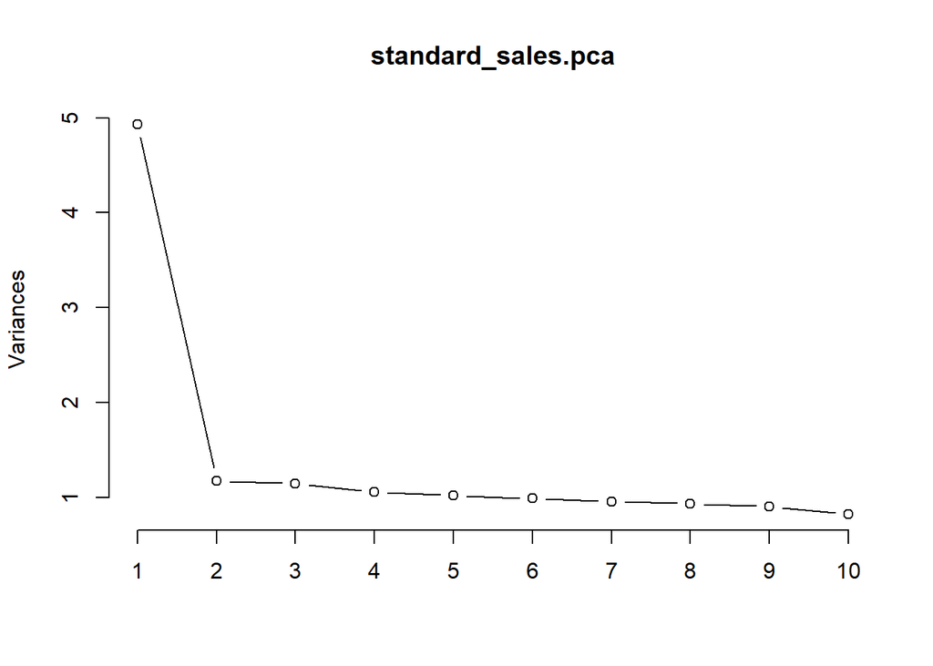

```r
screeplot(standard_sales.pca, type="lines")
```

#Loadings for the Principal Components

```r
standard_sales.pca$rotation[,1]
```

```
##      Unit.price        Quantity             Tax            cogs    gross.income
##   -0.2912116901   -0.3243982411   -0.4493304177   -0.4493304177   -0.4493304177
##          Rating           Total        Branch_E Customer_Type_E        Gender_E
##    0.0185885492   -0.4493304177   -0.0225875713    0.0125977368    0.0282511935
##  Product_Line_E       Payment_E           month             day
##   -0.0174785415    0.0078105867    0.0138018120    0.0008218282
```

calculate the values of the first principal component

```r
calcpc <- function(variables,loadings)
{
  # find the number of samples in the data set
  as.data.frame(variables)
  numsamples <- nrow(variables)
  # make a vector to store the component
  pc <- numeric(numsamples)
  # find the number of variables
  numvariables <- length(variables)
  # calculate the value of the component for each sample
  for (i in 1:numsamples)
  {
    valuei <- 0
    for (j in 1:numvariables)
    {
      valueij <- variables[i,j]
      loadingj <- loadings[j]
      valuei <- valuei + (valueij * loadingj)
    }
    pc[i] <- valuei
  }
  return(pc)
}
```

```r
calcpc(standard_sales, standard_sales.pca$rotation[,1])
```

[output not shown]

[output cut: 185 more lines]

```r
library(ggbiplot)
```

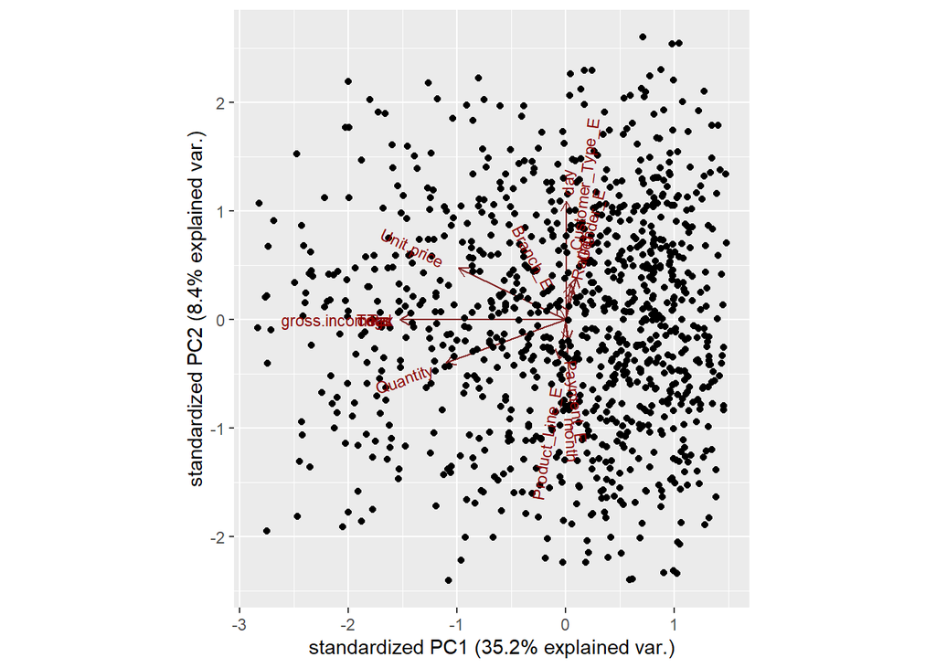

```r
ggbiplot(standard_sales.pca)
```

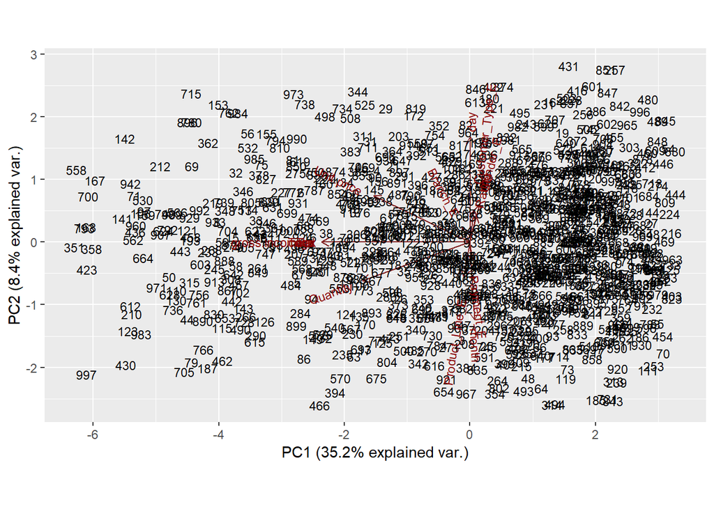

```r
ggbiplot(standard_sales.pca, labels=rownames(standard_sales), obs.scale = 1, var.scale = 1)
```

```r
#install.packages("Rtsne")
library(Rtsne)
tsne <- Rtsne(standard_sales, dims = 2, perplexity=30, verbose=TRUE, max_iter =
500)
```

```
## Performing PCA
## Read the 1000 x 14 data matrix successfully!
## OpenMP is working. 1 threads.
## Using no_dims = 2, perplexity = 30.000000, and theta = 0.500000
## Computing input similarities...
## Building tree...
## Done in 0.24 seconds (sparsity = 0.112096)!
## Learning embedding...
## Iteration 50: error is 70.905721 (50 iterations in 0.26 seconds)
## Iteration 100: error is 70.904864 (50 iterations in 0.19 seconds)
## Iteration 150: error is 70.488207 (50 iterations in 0.19 seconds)
## Iteration 200: error is 70.321966 (50 iterations in 0.17 seconds)
## Iteration 250: error is 70.322328 (50 iterations in 0.18 seconds)
## Iteration 300: error is 1.984250 (50 iterations in 0.17 seconds)
## Iteration 350: error is 1.800018 (50 iterations in 0.17 seconds)
## Iteration 400: error is 1.732045 (50 iterations in 0.17 seconds)
## Iteration 450: error is 1.705178 (50 iterations in 0.17 seconds)
## Iteration 500: error is 1.690270 (50 iterations in 0.17 seconds)
## Fitting performed in 1.84 seconds.
```

```r
standard_sales$Rating_num = as.integer(standard_sales$Rating)
```

```r
# Loading our tnse library
#
library(Rtsne)
```

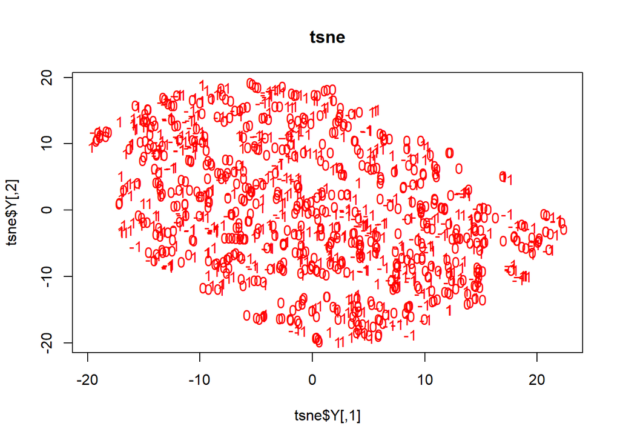

```r
#Preparing the database for analysis
Labels<-standard_sales$Rating_num
standard_sales$Rating_num<-as.factor(standard_sales$Rating_num)
# For plotting
colors = rainbow(length(standard_sales$Rating_num))
names(colors) = unique(standard_sales$Rating_num)
plot(tsne$Y, t='n', main="tsne")
text(tsne$Y, labels=standard_sales$Rating_num,
col=colors[standard_sales$Rating_num])
```

```r
# Curating the database for analysis
#
Labels<-standard_sales$Rating_num
standard_sales$Rating_num<-as.factor(standard_sales$Rating_num)
```

```r
# For plotting
#
colors = rainbow(length(unique(standard_sales$Rating_num)))
names(colors) = unique(standard_sales$Rating_num)
names(colors)
```

```
## [1] "1"  "0"  "-1"
```

```r
duplicated(standard_sales)
```

[output not shown]

[output cut: 69 more lines]

```r
# Executing the algorithm on curated data
#
tsne <- Rtsne(standard_sales[], dims = 2, perplexity=30, verbose=TRUE, max_iter = 500)
```

```
## Performing PCA
## Read the 1000 x 17 data matrix successfully!
## OpenMP is working. 1 threads.
## Using no_dims = 2, perplexity = 30.000000, and theta = 0.500000
## Computing input similarities...
## Building tree...
## Done in 0.27 seconds (sparsity = 0.112956)!
## Learning embedding...
## Iteration 50: error is 70.844790 (50 iterations in 0.29 seconds)
## Iteration 100: error is 70.844790 (50 iterations in 0.20 seconds)
## Iteration 150: error is 70.844607 (50 iterations in 0.20 seconds)
## Iteration 200: error is 70.778450 (50 iterations in 0.21 seconds)
## Iteration 250: error is 70.419254 (50 iterations in 0.19 seconds)
## Iteration 300: error is 1.976151 (50 iterations in 0.17 seconds)
## Iteration 350: error is 1.784315 (50 iterations in 0.17 seconds)
## Iteration 400: error is 1.727251 (50 iterations in 0.17 seconds)
## Iteration 450: error is 1.698781 (50 iterations in 0.17 seconds)
## Iteration 500: error is 1.684743 (50 iterations in 0.17 seconds)
## Fitting performed in 1.95 seconds.
```

```r
# Getting the duration of execution
#
exeTimeTsne <- system.time(Rtsne(standard_sales[,-1], dims = 2, perplexity=30, verbose=TRUE, max_iter = 500))
```

```
## Performing PCA
## Read the 1000 x 16 data matrix successfully!
## OpenMP is working. 1 threads.
## Using no_dims = 2, perplexity = 30.000000, and theta = 0.500000
## Computing input similarities...
## Building tree...
## Done in 0.23 seconds (sparsity = 0.113010)!
## Learning embedding...
## Iteration 50: error is 70.871386 (50 iterations in 0.22 seconds)
## Iteration 100: error is 70.871385 (50 iterations in 0.23 seconds)
## Iteration 150: error is 70.871296 (50 iterations in 0.28 seconds)
## Iteration 200: error is 70.861918 (50 iterations in 0.27 seconds)
## Iteration 250: error is 70.626104 (50 iterations in 0.30 seconds)
## Iteration 300: error is 1.817610 (50 iterations in 0.23 seconds)
## Iteration 350: error is 1.642481 (50 iterations in 0.26 seconds)
## Iteration 400: error is 1.585452 (50 iterations in 0.21 seconds)
## Iteration 450: error is 1.563851 (50 iterations in 0.22 seconds)
## Iteration 500: error is 1.546013 (50 iterations in 0.20 seconds)
## Fitting performed in 2.41 seconds.
```

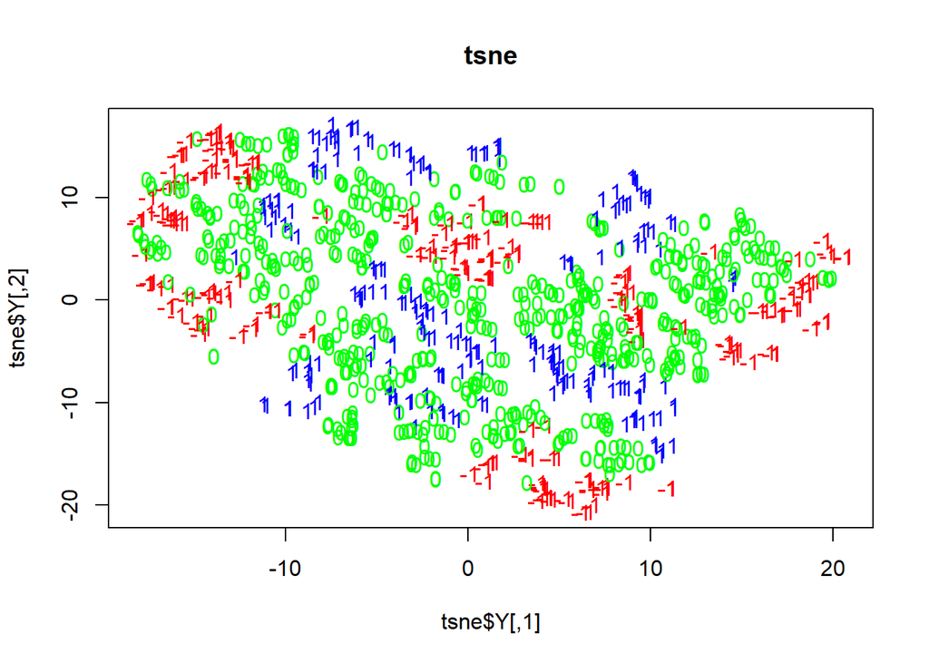

```r
# Plotting our graph and closely examining the graph
#
plot(tsne$Y, t='n', main="tsne")
text(tsne$Y, labels=standard_sales$Rating_num, col=colors[standard_sales$Rating_num])
```